# Arbres de régression

Karim Barigou

# 1 Modèles basés sur les arbres — CART

Dans cette section, nous étudierons l’utilisation des arbres CART (**C**lassification **A**nd **R**egression **T**rees), et plus particulièrement les arbres de régression utilisés pour prédire la fréquence des sinistres.

```r
# require("CASdatasets") - Non nécessaire, car les données ont été sauvegardées
# dans un fichier parquet
if (!require("rpart")) install.packages("rpart")
if (!require("rpart.plot")) install.packages("rpart.plot")
if (!require("arrow")) install.packages("arrow")
if (!require("caret")) install.packages("caret")
if (!require("ggplot2")) install.packages("ggplot2")
if (!require("rattle")) install.packages("rattle")
if (!require("dplyr")) install.packages("dplyr")

require("rpart")
require("rpart.plot")
require("arrow")
require("caret")
require("ggplot2")
require("rattle")
require("dplyr")

options(repr.plot.width = 8, repr.plot.height = 6, repr.plot.res = 150)
```

```r
dataset = read_parquet(file = "../data/dataset.parquet")
```

Lorsqu’on effectue de l’apprentissage automatique, une manière d’évaluer la capacité prédictive du modèle consiste à utiliser des données *nouvelles*, qui n’ont pas été utilisées lors de la phase d’*apprentissage*, puis à calculer une métrique de performance. Cela permet également de vérifier si le modèle est en situation de sur-ajustement.

Afin de disposer de données *nouvelles* à une étape ultérieure, il est courant de diviser le jeu de données en deux parties :

- un ensemble d’apprentissage. Ces données sont utilisées pour estimer et apprendre le modèle ;
- un ensemble de test. Ces données sont utilisées pour évaluer les performances du modèle une fois celui-ci entraîné.

Le package *caret* fournit de nombreuses fonctions utiles. L’une d’entre elles est *createDataPartition*. Nous allons maintenant diviser les données en deux parties — 80 % pour l’apprentissage et 20 % pour le test — en utilisant un échantillonnage stratifié. L’échantillonnage stratifié permet d’obtenir une distribution similaire du nombre de sinistres dans les ensembles d’apprentissage et de test.

```r
set.seed(21)

in_training = as.vector(
  createDataPartition(
    y = dataset$ClaimNb,
    times = 1,
    p = 0.8,
    list = FALSE
  )
)

training_set = dataset[in_training, ]
testing_set = dataset[-in_training, ]
```

Vérifions la distribution de la variable *ClaimNb* dans ces deux groupes.

```r
temp = dataset
temp$in_train_set = NA

temp[in_training, "in_train_set"] = 1
temp[-in_training, "in_train_set"] = 0

summary_table = 100 * round(
  prop.table(with(temp, table(in_train_set, ClaimNb)), 1),
  5
)

summary_table
```

```
##             ClaimNb
## in_train_set      0      1      2      3      4
##            0 96.316  3.502  0.174  0.006  0.001
##            1 96.254  3.562  0.176  0.007  0.001
```

```r
rm(temp)
```

```r
# Tirage aléatoire de 80 % des observations sans stratification
n = nrow(dataset)

train_indices = sample(
  1:n,
  size = 0.8 * n,
  replace = FALSE
)

# Création des ensembles d'apprentissage et de test
training_set_random = dataset[train_indices, ]
testing_set_random = dataset[-train_indices, ]

# Vérification de la distribution
temp = dataset
temp$in_train_set = NA

temp[train_indices, "in_train_set"] = 1
temp[-train_indices, "in_train_set"] = 0

summary_table_random = 100 * round(
  prop.table(with(temp, table(in_train_set, ClaimNb)), 1),
  5
)

summary_table_random
```

```
##             ClaimNb
## in_train_set      0      1      2      3      4
##            0 96.241  3.583  0.170  0.006  0.000
##            1 96.273  3.542  0.177  0.007  0.001
```

```r
rm(temp)
```

## 1.1 Package CART

Nous allons utiliser le package **rpart**, qui permet de construire des arbres de régression. Le package **rpart** peut être utilisé pour la régression et la classification. Il implémente également une méthode adaptée aux données suivant une loi de Poisson.

### 1.1.1 Exemple simple

Commençons par un exemple simple utilisant deux covariables :

```r
m0_rpart = rpart(
  cbind(Exposure, ClaimNb) ~ DriverAge + CarAge,
  data = training_set,
  method = "poisson",
  control = rpart.control(cp = 0.01)
)

summary(m0_rpart)
```

```
## Call:
## rpart(formula = cbind(Exposure, ClaimNb) ~ DriverAge + CarAge,
##     data = training_set, method = "poisson", control = rpart.control(cp = 0.01))
##   n= 328692
##
##            CP nsplit rel error xerror xstd
## 1 0.006462633      0         1      0    0
##
## Node number 1: 328692 observations
##   events=12944,  estimated rate=0.07025564 , mean deviance=0.256468
```

Nous constatons que l’arbre ne possède qu’un seul nœud et n’a pas été subdivisé. Cela provient du paramètre de complexité, qui pénalise les divisions de l’arbre. **Par défaut**, le paramètre de complexité est fixé à **cp = 0.01**, une valeur souvent trop élevée pour des données de Poisson présentant de faibles fréquences.

Fixons donc **cp = 0**. Afin de conserver un arbre de petite taille, nous imposerons également une profondeur maximale de 3.

```r
m0_rpart = rpart(
  cbind(Exposure, ClaimNb) ~ DriverAge + CarAge,
  data = training_set,
  control = rpart.control(
    cp = 0,
    maxdepth = 3
  )
)

summary(m0_rpart)
```

```
## Call:
## rpart(formula = cbind(Exposure, ClaimNb) ~ DriverAge + CarAge,
##     data = training_set, control = rpart.control(cp = 0, maxdepth = 3))
##   n= 328692
##
##             CP nsplit rel error    xerror        xstd
## 1 0.0064626327      0 1.0000000 1.0000288 0.006849993
## 2 0.0013751350      1 0.9935374 0.9942063 0.006792032
## 3 0.0011573505      2 0.9921622 0.9933225 0.006790267
## 4 0.0006268552      3 0.9910049 0.9919914 0.006781286
## 5 0.0003327416      4 0.9903780 0.9913345 0.006776254
## 6 0.0003102204      5 0.9900453 0.9913144 0.006776305
## 7 0.0001005746      6 0.9897351 0.9908459 0.006770940
## 8 0.0000000000      7 0.9896345 0.9908974 0.006771604
##
## Variable importance
## DriverAge    CarAge
##        88        12
##
## Node number 1: 328692 observations,    complexity param=0.006462633
##   events=12944,  estimated rate=0.07025564 , mean deviance=0.256468
##   left son=2 (302869 obs) right son=3 (25823 obs)
##   Primary splits:
##       DriverAge < 26.5 to the right, improve=544.79390, (0 missing)
##       CarAge    < 12.5 to the right, improve= 94.27821, (0 missing)
##
## Node number 2: 302869 observations,    complexity param=0.001157351
##   events=11443,  estimated rate=0.06615313 , mean deviance=0.2471847
##   left son=4 (61175 obs) right son=5 (241694 obs)
##   Primary splits:
##       CarAge    < 12.5 to the right, improve=97.56350, (0 missing)
##       DriverAge < 54.5 to the right, improve=76.38098, (0 missing)
##
## Node number 3: 25823 observations,    complexity param=0.001375135
##   events=1501,  estimated rate=0.1331876 , mean deviance=0.3442522
##   left son=6 (22085 obs) right son=7 (3738 obs)
##   Primary splits:
##       DriverAge < 20.5 to the right, improve=115.93870, (0 missing)
##       CarAge    < 4.5  to the left,  improve= 14.68241, (0 missing)
##
```

[output cut: 38 more lines]

```
##
## Node number 11: 175483 observations
##   events=6810,  estimated rate=0.07273823 , mean deviance=0.2487842
##
## Node number 12: 13410 observations
##   events=625,  estimated rate=0.103481 , mean deviance=0.2901859
##
## Node number 13: 8675 observations
##   events=530,  estimated rate=0.1400605 , mean deviance=0.358643
##
## Node number 14: 822 observations
##   events=50,  estimated rate=0.1634128 , mean deviance=0.3731759
##
## Node number 15: 2916 observations
##   events=296,  estimated rate=0.2544343 , mean deviance=0.4902952
```

### 1.1.2 Comprendre la division optimale

Essayons de comprendre pourquoi la première division utilise la règle suivante :

```
DriverAge < 26.5
```

Considérons les différentes façons possibles de diviser les données à partir de la variable *DriverAge*.

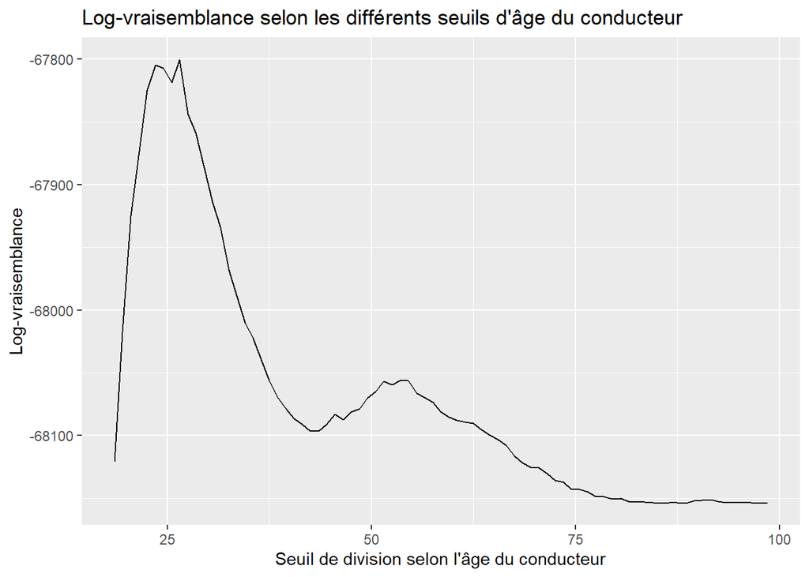

```r
ages = seq(18.5, 98.5, 1)

loglik = sapply(ages, function(age) {
  # Définition d'un indicateur permettant de diviser les données
  dataset$DriverAge_indicator = dataset$DriverAge < age

  # Calcul de la fréquence des sinistres de chaque côté de la division
  temp = dataset %>%
    group_by(DriverAge_indicator) %>%
    summarise(
      claim_freq = sum(ClaimNb) / sum(Exposure)
    )

  # Attribution de la fréquence des sinistres à chaque ligne du jeu de données
  dataset = dataset %>%
    left_join(temp, by = "DriverAge_indicator")

  # Calcul de la log-vraisemblance
  return(
    with(
      dataset,
      sum(
        dpois(
          x = ClaimNb,
          lambda = Exposure * claim_freq,
          log = TRUE
        )
      )
    )
  )

  # Calcul de la log-vraisemblance à partir de la formule explicite
  # return(with(dataset, sum(
  #   ClaimNb * log(Exposure * claim_freq) -
  #   Exposure * claim_freq -
  #   lfactorial(ClaimNb)
  # )))
})

plotdata = data.frame(
  DriverAge = ages,
  loglik = loglik
)

ggplot(plotdata) +
  geom_line(aes(x = DriverAge, y = loglik)) +
  labs(
    title = "Log-vraisemblance selon les différents seuils d'âge du conducteur",
    x = "Seuil de division selon l'âge du conducteur",
    y = "Log-vraisemblance"
  )
```

```r
# Affichage des cinq seuils produisant les plus grandes
# valeurs de log-vraisemblance
head(
  plotdata[order(-plotdata$loglik), ],
  5
)
```

```
##   DriverAge    loglik
## 9      26.5 -67800.14
## 6      23.5 -67804.40
## 7      24.5 -67807.10
## 8      25.5 -67818.57
## 5      22.5 -67824.61
```

Nous constatons que la règle `DriverAge < 26.5` correspond effectivement à la division optimale.

### 1.1.3 Représenter un arbre

La manière la plus simple d’interpréter un arbre CART consiste probablement à le représenter graphiquement — à condition qu’il ne soit pas trop grand. Cela peut être réalisé avec la fonction *rpart.plot* du package *rpart.plot*.

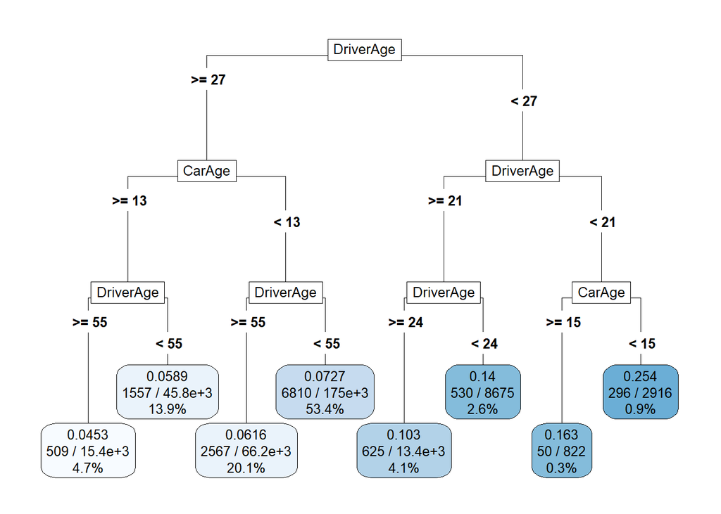

```r
rpart.plot(
  m0_rpart,
  type = 5,
  extra = 101,
  under = FALSE,
  fallen.leaves = TRUE,
  digits = 3
)
```

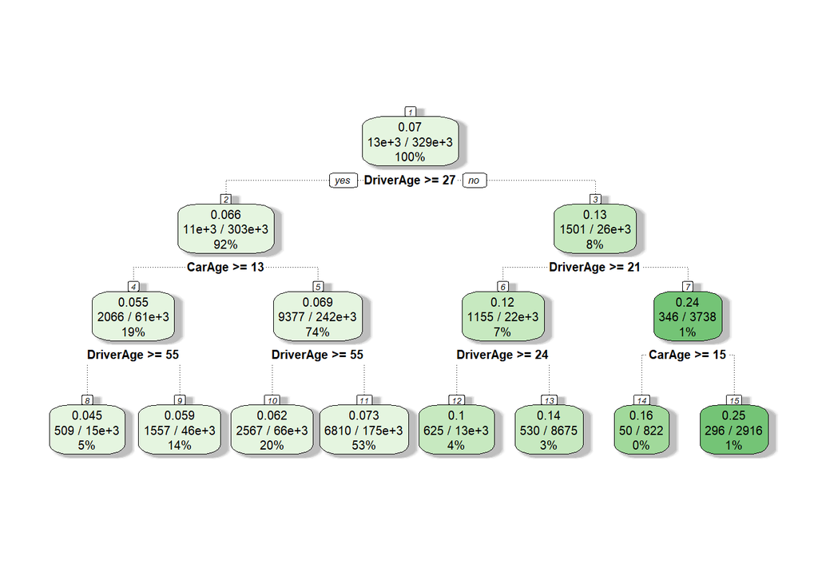

```r
# À titre informatif : représentation avec le package rattle
fancyRpartPlot(
  m0_rpart,
  split.col = "black",
  nn.col = "black",
  caption = "",
  digits = 2
)
```

Si l’arbre est trop grand, il est probablement en situation de sur-ajustement. Pour éviter ce problème, nous pouvons agir sur le paramètre de complexité *cp*. Une bonne approche consiste à construire l’arbre complet, sans pénalité — c’est-à-dire avec un paramètre de complexité égal à 0 — puis à élaguer cet arbre afin d’obtenir un sous-arbre.

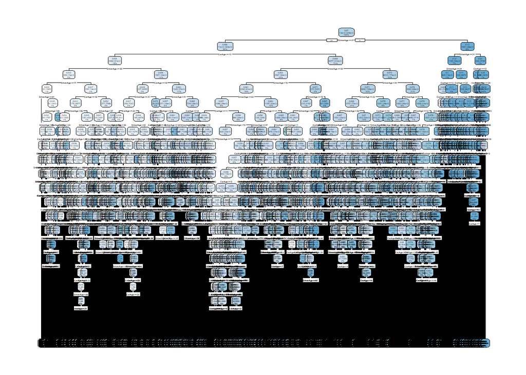

```r
m0_rpart = rpart(
  cbind(Exposure, ClaimNb) ~ DriverAge + CarAge,
  data = training_set,
  control = rpart.control(cp = 0)
)

rpart.plot(m0_rpart)
```

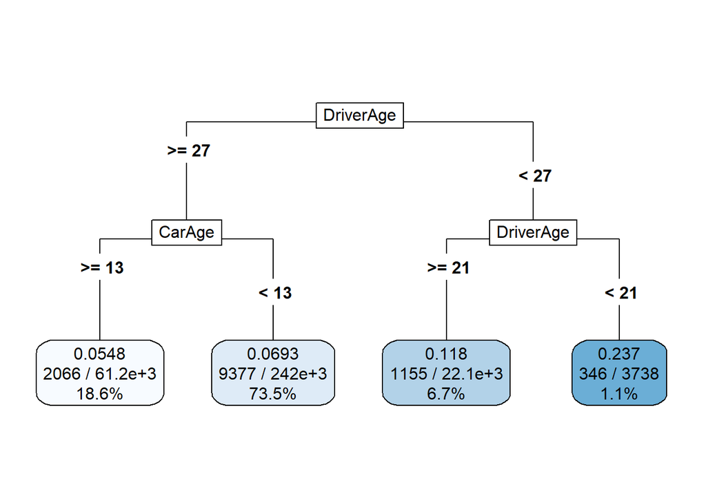

```r
rpart.plot(
  prune(m0_rpart, cp = 9e-04),
  type = 5,
  extra = 101,
  under = FALSE,
  fallen.leaves = TRUE,
  digits = 3
)
```

Nous constatons également que, dans certains nœuds terminaux — c’est-à-dire les feuilles — le nombre d’observations et le nombre de sinistres sont très faibles. Nous pouvons imposer un nombre minimal d’observations dans chaque nœud terminal à l’aide du paramètre *minbucket*.

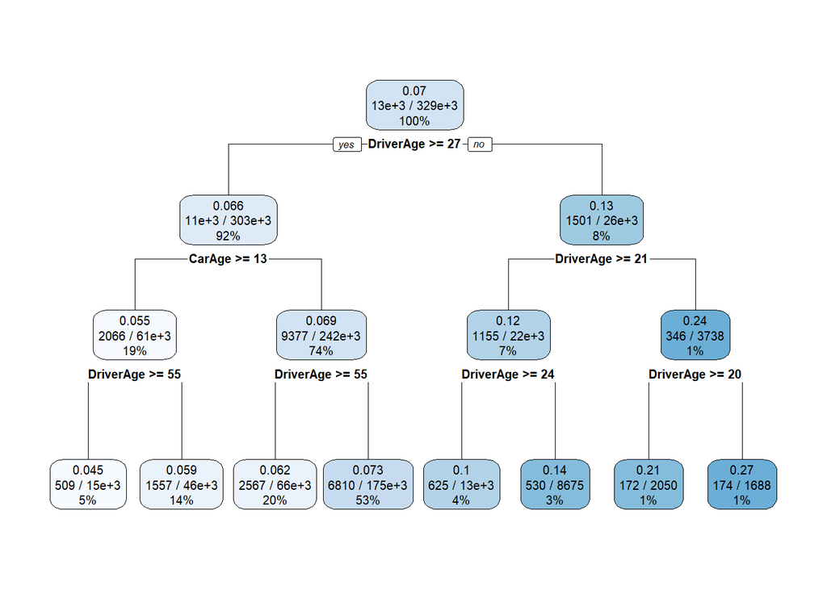

```r
m0_rpart = rpart(
  cbind(Exposure, ClaimNb) ~ DriverAge + CarAge,
  data = training_set,
  control = rpart.control(
    cp = 0,
    maxdepth = 3,
    minbucket = 1000
  )
)

rpart.plot(m0_rpart)
```

## 1.2 Paramètre de complexité

La modification du paramètre de complexité permet d’obtenir différents sous-arbres de l’arbre complètement développé — c’est-à-dire l’arbre obtenu avec `cp = 0`.

Vérifions, à l’aide d’un exemple, qu’une augmentation du paramètre de complexité *cp* conduit uniquement à un élagage différent de l’arbre et qu’elle produit bien un **sous-arbre**. Les parties communes aux trois arbres ci-dessous — notamment la première division — sont identiques.

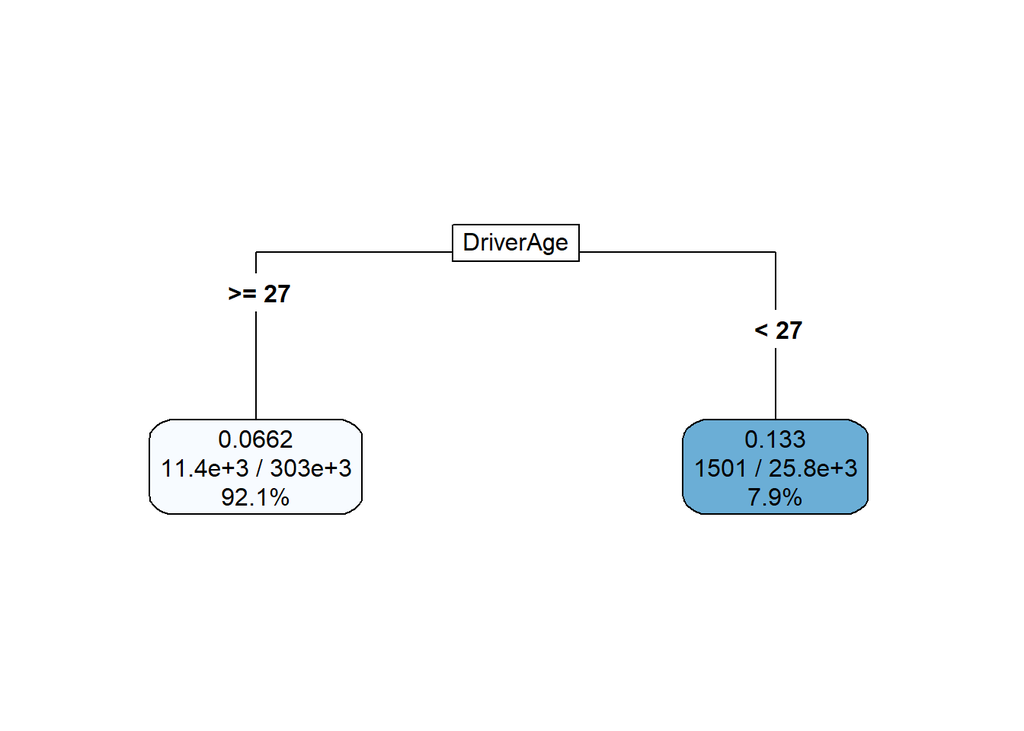

```r
tree1 = rpart(
  cbind(Exposure, ClaimNb) ~ DriverAge + CarAge,
  data = training_set,
  control = rpart.control(cp = 0.0063)
)

rpart.plot(
  tree1,
  type = 5,
  extra = 101,
  under = FALSE,
  fallen.leaves = TRUE,
  digits = 3
)
```

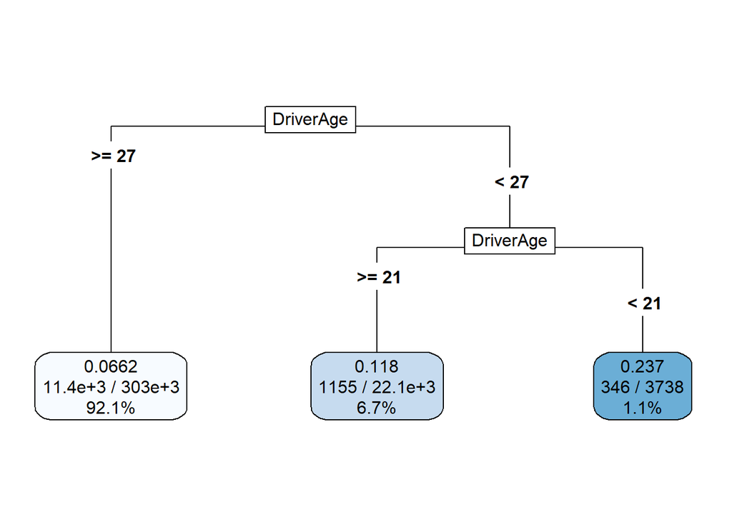

```r
tree2 = rpart(
  cbind(Exposure, ClaimNb) ~ DriverAge + CarAge,
  data = training_set,
  control = rpart.control(cp = 0.0013)
)

rpart.plot(
  tree2,
  type = 5,
  extra = 101,
  under = FALSE,
  fallen.leaves = TRUE,
  digits = 3
)
```

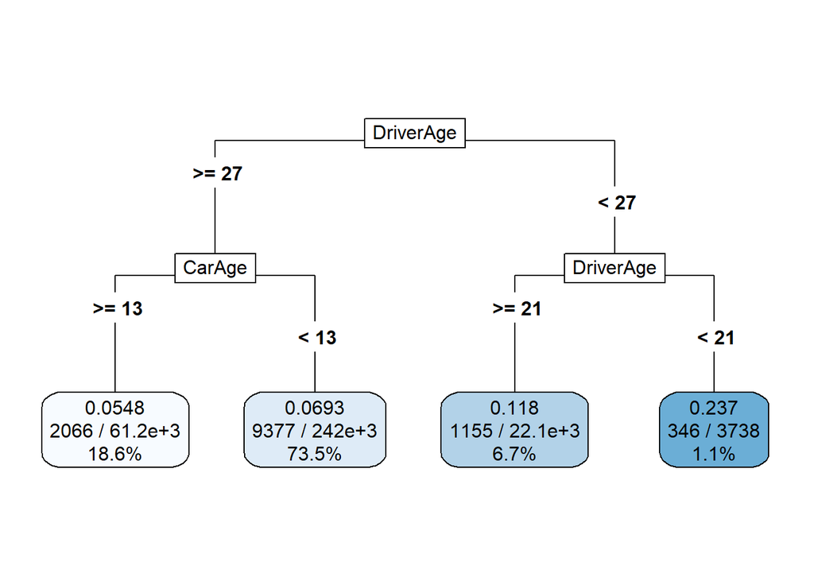

```r
tree3 = rpart(
  cbind(Exposure, ClaimNb) ~ DriverAge + CarAge,
  data = training_set,
  control = rpart.control(cp = 0.0011)
)

rpart.plot(
  tree3,
  type = 5,
  extra = 101,
  under = FALSE,
  fallen.leaves = TRUE,
  digits = 3
)
```

## 1.3 Validation croisée

Cherchons maintenant l’arbre optimal à l’aide de la validation croisée. Dans cette section, nous utiliserons uniquement les variables *DriverAge* et *CarAge*.

Par défaut, **rpart** effectue une validation croisée à 10 plis en utilisant l’option `xval = 10`.

> Remarque : le fonctionnement détaillé de la validation croisée est décrit dans la section 4.2 de la vignette de **rpart** : https://cran.r-project.org/web/packages/rpart/vignettes/longintro.pdf

De manière simplifiée, la méthode peut être résumée comme suit :

1. Nous estimons l’arbre complet avec `cp = 0` sur l’ensemble des données. Nous obtenons une liste de paramètres de complexité `αᵢ`. Nous définissons les valeurs `βᵢ` comme la moyenne géométrique de deux valeurs `αᵢ` successives. À chaque valeur `βᵢ` correspond un sous-arbre de l’arbre complet.
2. Nous divisons l’ensemble des données en plusieurs sous-ensembles — généralement 10 plis.
   - Nous estimons l’arbre en utilisant tous les plis sauf un.
   - À partir de la liste des valeurs `βᵢ` obtenue à l’étape précédente, nous élaguons l’arbre afin d’obtenir différents sous-arbres.
   - Nous calculons la fonction de perte — le risque — de ces sous-arbres sur le pli laissé de côté. Pour chaque valeur `βᵢ`, nous obtenons une perte.
   - Nous répétons cette opération pour tous les plis. Pour chaque valeur `βᵢ`, nous obtenons autant de pertes qu’il y a de plis.
   - Nous agrégeons ces pertes par sommation. Après agrégation, chaque valeur `βᵢ` est associée à une seule perte.
3. Le paramètre de complexité optimal `cp*` est défini comme la valeur `βᵢ` associée à la plus petite perte. L’arbre optimal est alors le sous-arbre correspondant à la valeur `cp = cp*`.

```r
m0_rpart = rpart(
  cbind(Exposure, ClaimNb) ~ DriverAge + CarAge,
  data = training_set,
  control = rpart.control(
    cp = 3e-5,
    xval = 10
  )
)

printcp(m0_rpart)
```

```
##
## Rates regression tree:
## rpart(formula = cbind(Exposure, ClaimNb) ~ DriverAge + CarAge,
##     data = training_set, control = rpart.control(cp = 3e-05,
##         xval = 10))
##
## Variables actually used in tree construction:
## [1] CarAge    DriverAge
##
## Root node error: 84299/328692 = 0.25647
##
## n= 328692
##
##            CP nsplit rel error  xerror      xstd
## 1  6.4626e-03      0   1.00000 1.00002 0.0068500
```

[output cut: 77 more lines]

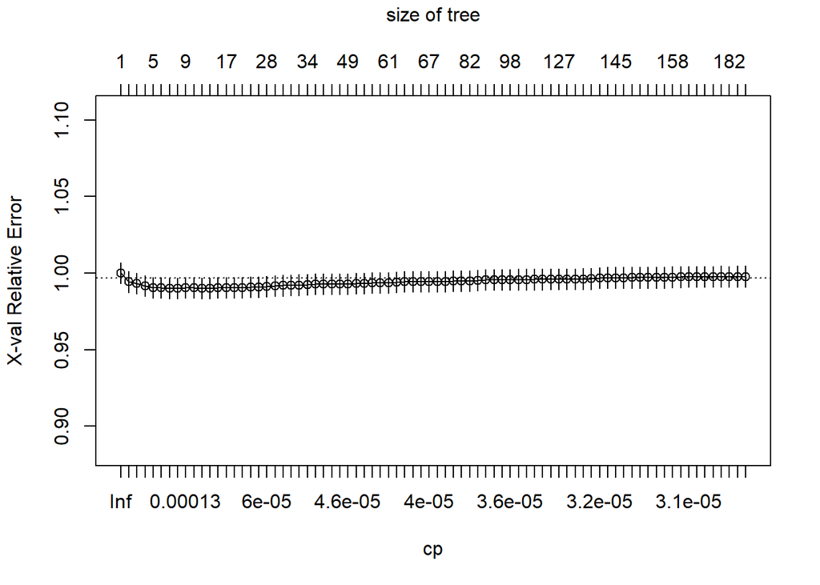

```r
plotcp(m0_rpart)
```

```r
head(m0_rpart$cptable, 10)
```

```
##              CP nsplit rel error    xerror        xstd
## 1  0.0064626327      0 1.0000000 1.0000243 0.006850019
## 2  0.0013751350      1 0.9935374 0.9942206 0.006791312
## 3  0.0011573505      2 0.9921622 0.9932076 0.006786700
## 4  0.0006268552      3 0.9910049 0.9915061 0.006776897
## 5  0.0003327416      4 0.9903780 0.9905466 0.006766591
## 6  0.0003102204      5 0.9900453 0.9903166 0.006764007
## 7  0.0002128410      6 0.9897351 0.9900452 0.006762081
## 8  0.0001403828      7 0.9895222 0.9900864 0.006762349
## 9  0.0001213919      8 0.9893818 0.9902814 0.006763529
## 10 0.0001207448      9 0.9892604 0.9902893 0.006763869
```

Examinons maintenant l’arbre optimal.

```r
cp_star = m0_rpart$cptable[
  which.min(m0_rpart$cptable[, "xerror"]),
  "CP"
]

print(cp_star)
```

```
## [1] 0.000212841
```

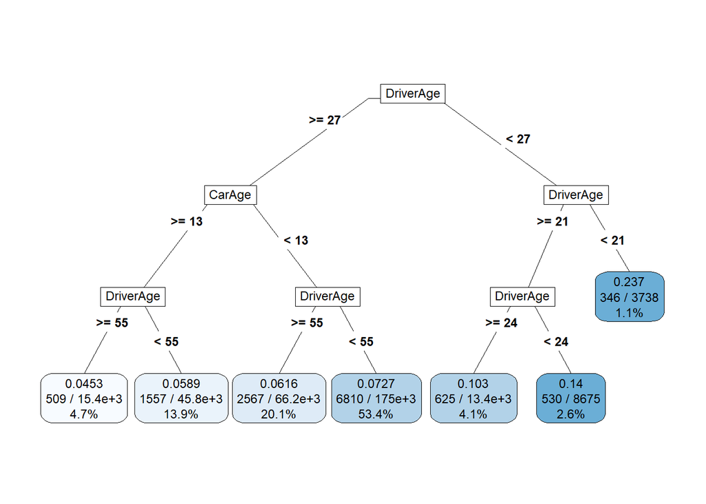

```r
rpart.plot(
  prune(m0_rpart, cp = cp_star),
  type = 5,
  extra = 101,
  under = FALSE,
  fallen.leaves = FALSE,
  digits = 3
)
```

## 1.4 Utilisation de toutes les covariables

Incluons maintenant toutes les covariables du jeu de données.

```r
m1_rpart = rpart(
  cbind(Exposure, ClaimNb) ~
    Power + CarAge + DriverAge + Brand +
    Gas + Region + Density,
  data = training_set,
  method = "poisson",
  control = rpart.control(
    cp = 0,
    xval = 10,
    minbucket = 1000
  )
)

printcp(m1_rpart)
```

```
##
## Rates regression tree:
## rpart(formula = cbind(Exposure, ClaimNb) ~ Power + CarAge + DriverAge +
##     Brand + Gas + Region + Density, data = training_set, method = "poisson",
##     control = rpart.control(cp = 0, xval = 10, minbucket = 1000))
##
## Variables actually used in tree construction:
## [1] Brand     CarAge    Density   DriverAge Gas       Power     Region
##
## Root node error: 84299/328692 = 0.25647
##
## n= 328692
##
##             CP nsplit rel error  xerror      xstd
## 1   6.4626e-03      0   1.00000 1.00001 0.0068498
```

[output cut: 130 more lines]

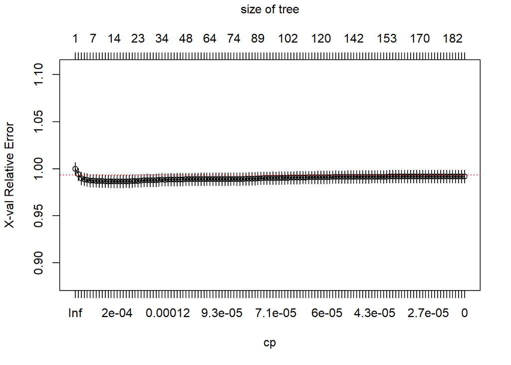

```r
plotcp(
  x = m1_rpart,
  minline = TRUE,
  col = "red"
)
```

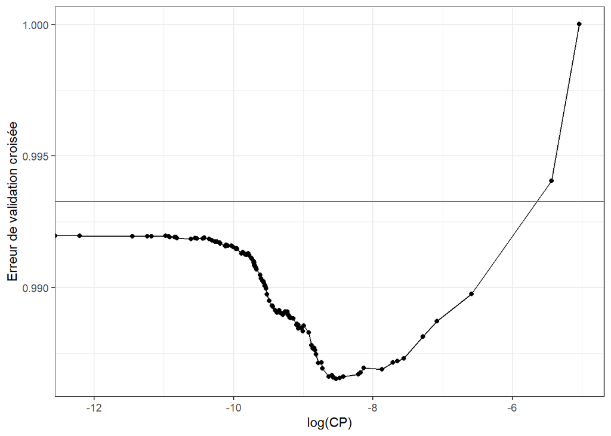

```r
# Calcul de la frontière correspondant à la règle des 1 écart-types
SE = m1_rpart$cptable[
  which.min(m1_rpart$cptable[, 4]),
  5
]

min_error = m1_rpart$cptable[
  which.min(m1_rpart$cptable[, 4]),
  4
]

boundary = min_error + SE

# Représentation de l'erreur de validation croisée et de la frontière
# correspondant à la règle des 1 écart-types en fonction de log(cp)
ggplot() +
  geom_line(
    aes(
      x = log(m1_rpart$cptable[, 1]),
      y = m1_rpart$cptable[, 4]
    )
  ) +
  geom_point(
    aes(
      x = log(m1_rpart$cptable[, 1]),
      y = m1_rpart$cptable[, 4]
    )
  ) +
  geom_hline(
    aes(yintercept = boundary),
    color = "red"
  ) +
  scale_x_continuous(name = "log(CP)") +
  scale_y_continuous(name = "Erreur de validation croisée") +
  theme_bw()
```

Si nous retenons la valeur de *cp* qui minimise l’erreur, nous obtenons :

```r
cp_star = m1_rpart$cptable[
  which.min(m1_rpart$cptable[, 4]),
  1
]

log(cp_star)
```

```
## [1] -8.532595
```

Représentons maintenant l’arbre optimal.

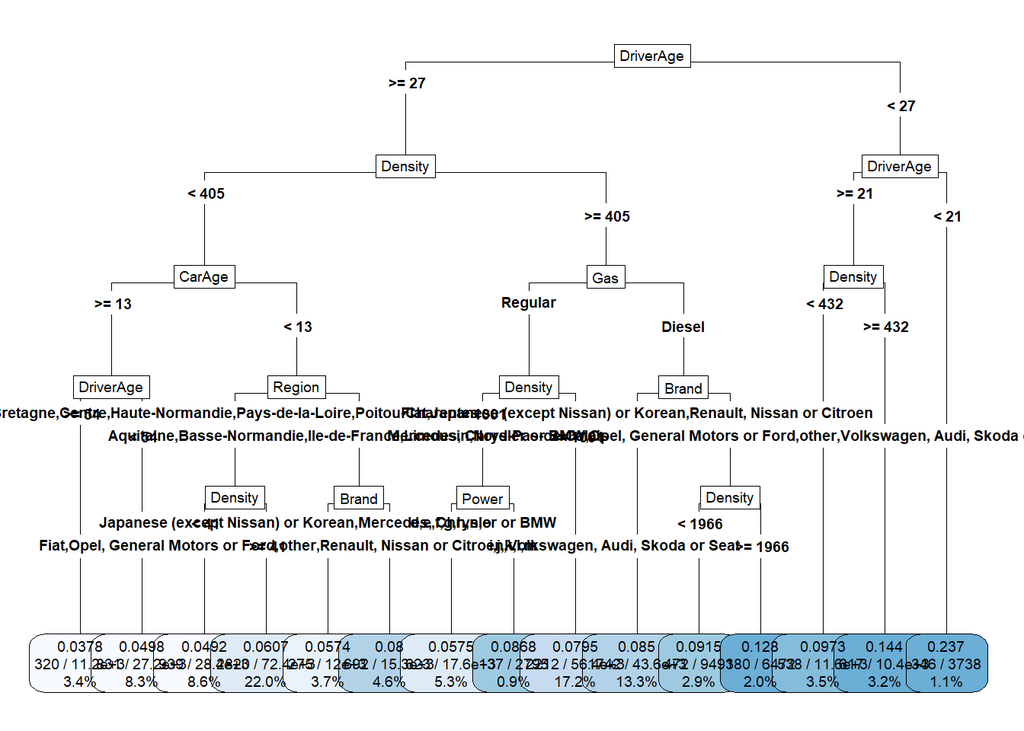

```r
m2_rpart = prune(
  m1_rpart,
  cp = cp_star
)

rpart.plot(
  m2_rpart,
  type = 5,
  extra = 101,
  under = FALSE,
  fallen.leaves = TRUE,
  digits = 3,
  cex = 0.60
)
```

Il est possible d’extraire une mesure de l’importance des variables. Cette mesure correspond aux gains obtenus sur la fonction de perte grâce à chacune des variables.

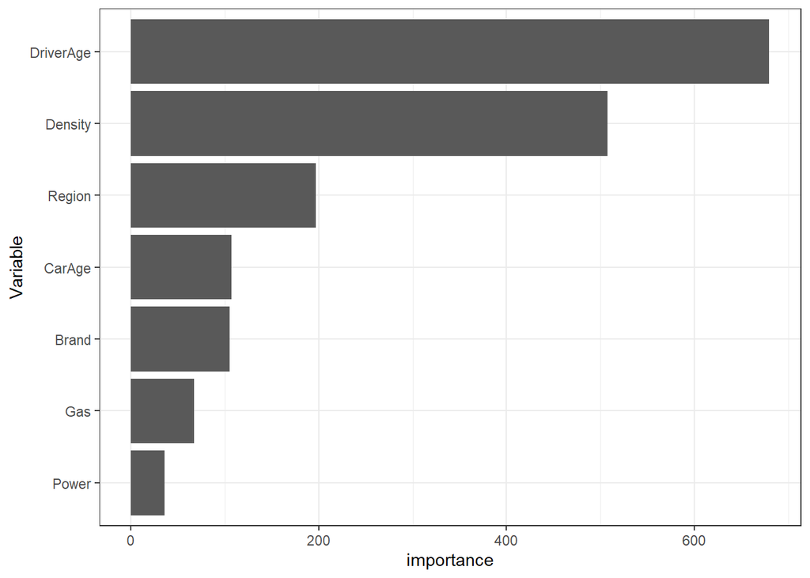

```r
plotdata = data.frame(m2_rpart$variable.importance)
names(plotdata) = "importance"
plotdata$var = rownames(plotdata)

ggplot(
  plotdata,
  aes(
    x = reorder(var, importance),
    y = importance
  )
) +
  geom_bar(stat = "identity") +
  coord_flip() +
  scale_x_discrete(name = "Variable") +
  theme_bw()
```

Calculons enfin la déviance sur l’ensemble de test.

```r
deviance_poisson = function(x_obs, x_pred) {
  2 * (
    sum(dpois(
      x = x_obs,
      lambda = x_obs,
      log = TRUE
    )) -
      sum(dpois(
        x = x_obs,
        lambda = x_pred,
        log = TRUE
      ))
  )
}

deviance_poisson(
  x_obs = testing_set$ClaimNb,
  x_pred = predict(m2_rpart, testing_set) *
    testing_set$Exposure
)
```

```
## [1] 20511.47
```

Si nous calculons la déviance sur l’arbre complet — et non sur l’arbre élagué — nous obtenons :

```r
deviance_poisson(
  x_obs = testing_set$ClaimNb,
  x_pred = predict(m1_rpart, testing_set) *
    testing_set$Exposure
)
```

```
## [1] 20661.82
```

# 2 Instabilité des arbres

Afin d’illustrer la sensibilité des arbres aux données, comparons :

- un arbre construit à partir de l’ensemble du jeu d’apprentissage ;
- un arbre construit de manière similaire à partir d’un sous-échantillon aléatoire — environ un tiers de l’ensemble d’apprentissage.

```r
rpart(
  cbind(Exposure, ClaimNb) ~
    Power + CarAge + DriverAge + Brand +
    Gas + Region + Density,
  data = training_set,
  method = "poisson",
  control = rpart.control(
    cp = 0,
    maxdepth = 2,
    xval = 0
  )
)
```

```
## n= 328692
##
## node), split, n, deviance, yval
##       * denotes terminal node
##
## 1) root 328692 84298.990 0.07025564
##   2) DriverAge>=26.5 302869 74864.570 0.06615313
##     4) Density< 404.5 166485 39539.050 0.05643207 *
##     5) Density>=404.5 136384 34958.700 0.08086143 *
##   3) DriverAge< 26.5 25823  8889.624 0.13318760
##     6) DriverAge>=20.5 22085  7028.772 0.11764220 *
##     7) DriverAge< 20.5 3738  1744.930 0.23683500 *
```

```r
set.seed(5)

rpart(
  cbind(Exposure, ClaimNb) ~
    Power + CarAge + DriverAge + Brand +
    Gas + Region + Density,
  data = training_set[
    sample(
      1:nrow(training_set),
      100000,
      replace = FALSE
    ),
  ],
  method = "poisson",
  control = rpart.control(
    cp = 0,
    maxdepth = 2,
    xval = 0
  )
)
```

```
## n= 100000
##
## node), split, n, deviance, yval
##       * denotes terminal node
##
## 1) root 100000 25551.0800 0.06976625
##   2) Density< 563.5 60083 14638.1600 0.05920391
##     4) DriverAge>=24.5 57197 13540.0000 0.05650294 *
##     5) DriverAge< 24.5 2886  1005.5330 0.13238650 *
##   3) Density>=563.5 39917 10747.8600 0.08988806
##     6) DriverAge>=23.5 38463 10081.7100 0.08655894 *
##     7) DriverAge< 23.5 1454   607.6877 0.19581670 *
```

## 2.1 Agrégation d’arbres — bagging

Créons les échantillons bootstrap.

```r
set.seed(85)

bootstrap_samples = createResample(
  training_set$ClaimNb,
  times = 50
)
```

Pour chaque échantillon, nous estimons un modèle CART avec le paramètre de complexité optimal déterminé précédemment. Chaque arbre fournit une estimation de la fréquence des sinistres, puis nous calculons la moyenne de ces estimations.

```r
bagg_cart = lapply(bootstrap_samples, function(X) {
  rpart(
    cbind(Exposure, ClaimNb) ~
      Power + CarAge + DriverAge + Brand +
      Gas + Region + Density,
    data = training_set[X, ],
    method = "poisson",
    control = rpart.control(
      cp = cp_star,
      xval = 0
    )
  )
})
```

```r
pred = lapply(bagg_cart, function(X) {
  predict(X, testing_set) *
    testing_set$Exposure
})

pred = do.call(cbind, pred)
```

```r
pred = apply(pred, 1, mean)
```

```r
deviance_poisson(
  x_obs = testing_set$ClaimNb,
  x_pred = pred
)
```

```
## [1] 20448.69
```